# NHL Play by Play Featuring Detroit 2023-24

Author

Anthony Mollica

## Installing Data

```r
#install.packages("hockeyR")
#install.packages("devtools")
devtools::install_github("danmorse314/hockeyR")
devtools::install_github("jamesmartherus/shotplot")
devtools::source_url("https://raw.githubusercontent.com/mrbilltran/the-win-column/master/nhl_rink_plot.R")
library(hockeyR)
library(sportyR)
library(tidyverse)
library(devtools)
library(png)
library(grid)
library(jsonlite)
library(curl)
library(shotplot)
library(knitr)
geom_shotplot <- function(...){
  list(annotation_custom(grid::rasterGrob(png::readPNG(here::here("man/figures/full-rink.png")),
                                                                  width = unit(1,"npc"),
                                                                  height = unit(1,"npc"))),
  geom_point(),
  coord_flip())
}
```

## Introduction:

Being a huge Detroit Red Wings fan like myself, I decided to dive into a data set where I could analyse some of the pro’s and the cons that the Wing’s faced this season. Unfortunately the Wing’s did not make the Stanley Cup Playoff’s by a very close call; they lost the head to head match over the Capitals and just fell short as they were tied for points. In the National Hockey League a win counts as 2 points a tie counts as 1 and a loss counts as 0, so every game is critical. Being a hockey player I decided to do a small scouting report on the Wings analyzing four main things: penalties taken, blocked shots, power play conversions, and goals scored. For these categories what can the Wing’s do better to be prepared for the 2024-25 season in order to make the 2025 Stanley Cup Playoff’s?

## Data Sets Used:

The data set that I chose to use is a set that has every single play from the NHL from the start to the end of the 2023-2024 regular season. The ‘pbp’ data set had originally 425,751 observations and 138 variables. When I filtered it just to the Red Wings pbp to be ‘Wingspbp’ it had 10094 observations and 138 variables. Then I filtered ‘Wingspbp’ to just Red Wings goals to ‘Wingsgoals’ which had 280 observations and 138 variables. Each of these three data sets were used a lot throughout my whole project.

```r
pbp <- load_pbp('2023-24')##Every NHL team play by play
Wingspbp <- pbp|> filter(event_team == "Detroit Red Wings") ##Redwings play by play
Wingsgoals <- Wingspbp|> filter(event_type == "GOAL")|> ##Redwings goals
  mutate(secondary_type = fct_collapse(secondary_type,
                                       wrist_snap = c("wrist", "snap"),
                                       deflect_tip = c("deflected", "tip-in"),
                                       trick = c("between-legs", "poke", "wrap-around")))

head(pbp)|> kable()
```

| event_type | event | secondary_type | event_team | event_team_type | description | period | period_seconds | period_seconds_remaining | game_seconds | game_seconds_remaining | home_score | away_score | event_player_1_name | event_player_1_type | event_player_2_name | event_player_2_type | event_player_3_name | event_player_3_type | event_goalie_name | strength_state | strength_code | strength | event_idx | num_on | players_on | num_off | players_off | extra_attacker | x | … |
| --- | --- | --- | --- | --- | --- | --- | --- | --- | --- | --- | --- | --- | --- | --- | --- | --- | --- | --- | --- | --- | --- | --- | --- | --- | --- | --- | --- | --- | --- | --- |
| PERIOD_START | period-start | NA | NA | NA | Start of Period 1 | 1 | 0 | 1200 | 0 | 3600 | 0 | 0 | NA | NA | NA | NA | NA | NA | NA | 5v5 | NA | NA | 0000 | NA | NA | NA | NA | FALSE | NA | … |
| FACEOFF | faceoff | NA | Pittsburgh Penguins | home | Sidney Crosby faceoff won against Connor Bedard | 1 | 0 | 1200 | 0 | 3600 | 0 | 0 | Sidney Crosby | Winner | Connor Bedard | Loser | NA | NA | NA | 5v5 | EV | Even | 0003 | NA | NA | NA | NA | FALSE | 0 | … |
| HIT | hit | NA | Pittsburgh Penguins | home | Jake Guentzel hit Seth Jones | 1 | 35 | 1165 | 35 | 3565 | 0 | 0 | Jake Guentzel | Hitter | Seth Jones | Hittee | NA | NA | NA | 5v5 | EV | Even | 0004 | NA | NA | NA | NA | FALSE | 75 | … |
| SHOT | shot-on-goal | backhand | Pittsburgh Penguins | home | Bryan Rust shot on goal saved by Petr Mrazek | 1 | 40 | 1160 | 40 | 3560 | 0 | 0 | Bryan Rust | Shooter | Petr Mrazek | Goalie | NA | NA | Petr Mrazek | 5v5 | EV | Even | 0006 | NA | NA | NA | NA | FALSE | -51 | … |
| SHOT | shot-on-goal | wrist | Chicago Blackhawks | away | Kevin Korchinski shot on goal saved by Tristan Jarry | 1 | 59 | 1141 | 59 | 3541 | 0 | 0 | Kevin Korchinski | Shooter | Tristan Jarry | Goalie | NA | NA | Tristan Jarry | 5v5 | EV | Even | 0013 | NA | NA | NA | NA | FALSE | -55 | … |
| STOP | stoppage | NA | NA | NA | Stoppage in play (puck-in-netting) | 1 | 62 | 1138 | 62 | 3538 | 0 | 0 | NA | NA | NA | NA | NA | NA | NA | 5v5 | EV | Even | 0014 | NA | NA | NA | NA | FALSE | NA | … |

```r
head(Wingspbp)|> kable()
```

| event_type | event | secondary_type | event_team | event_team_type | description | period | period_seconds | period_seconds_remaining | game_seconds | game_seconds_remaining | home_score | away_score | event_player_1_name | event_player_1_type | event_player_2_name | event_player_2_type | event_player_3_name | event_player_3_type | event_goalie_name | strength_state | strength_code | strength | event_idx | num_on | players_on | num_off | players_off | extra_attacker | x | … |
| --- | --- | --- | --- | --- | --- | --- | --- | --- | --- | --- | --- | --- | --- | --- | --- | --- | --- | --- | --- | --- | --- | --- | --- | --- | --- | --- | --- | --- | --- | --- |
| FACEOFF | faceoff | NA | Detroit Red Wings | away | Dylan Larkin faceoff won against Nico Hischier | 1 | 0 | 1200 | 0 | 3600 | 0 | 0 | Dylan Larkin | Winner | Nico Hischier | Loser | NA | NA | NA | 5v5 | EV | Even | 0003 | NA | NA | NA | NA | FALSE | 0 | … |
| SHOT | shot-on-goal | slap | Detroit Red Wings | away | David Perron shot on goal saved by Vitek Vanecek | 1 | 8 | 1192 | 8 | 3592 | 0 | 0 | David Perron | Shooter | Vitek Vanecek | Goalie | NA | NA | Vitek Vanecek | 5v5 | EV | Even | 0006 | NA | NA | NA | NA | FALSE | -71 | … |
| HIT | hit | NA | Detroit Red Wings | away | David Perron hit Kevin Bahl | 1 | 12 | 1188 | 12 | 3588 | 0 | 0 | David Perron | Hitter | Kevin Bahl | Hittee | NA | NA | NA | 5v5 | EV | Even | 0007 | NA | NA | NA | NA | FALSE | -78 | … |
| MISSED_SHOT | missed-shot | snap | Detroit Red Wings | away | Alex DeBrincat shot missed wide of net | 1 | 20 | 1180 | 20 | 3580 | 0 | 0 | Alex DeBrincat | Shooter | Vitek Vanecek | Goalie | NA | NA | Vitek Vanecek | 5v5 | EV | Even | 0008 | NA | NA | NA | NA | FALSE | -68 | … |
| FACEOFF | faceoff | NA | Detroit Red Wings | away | J.T. Compher faceoff won against Nico Hischier | 1 | 28 | 1172 | 28 | 3572 | 0 | 0 | J.T. Compher | Winner | Nico Hischier | Loser | NA | NA | NA | 5v5 | EV | Even | 0011 | NA | NA | NA | NA | FALSE | -69 | … |
| BLOCKED_SHOT | blocked-shot | NA | Detroit Red Wings | away | Moritz Seider shot blocked by Dawson Mercer | 1 | 31 | 1169 | 31 | 3569 | 0 | 0 | Moritz Seider | Shooter | Dawson Mercer | Blocker | NA | NA | NA | 5v5 | EV | Even | 0012 | NA | NA | NA | NA | FALSE | -42 | … |

```r
head(Wingsgoals)|> kable()
```

| event_type | event | secondary_type | event_team | event_team_type | description | period | period_seconds | period_seconds_remaining | game_seconds | game_seconds_remaining | home_score | away_score | event_player_1_name | event_player_1_type | event_player_2_name | event_player_2_type | event_player_3_name | event_player_3_type | event_goalie_name | strength_state | strength_code | strength | event_idx | num_on | players_on | num_off | players_off | extra_attacker | x | … |
| --- | --- | --- | --- | --- | --- | --- | --- | --- | --- | --- | --- | --- | --- | --- | --- | --- | --- | --- | --- | --- | --- | --- | --- | --- | --- | --- | --- | --- | --- | --- |
| GOAL | goal | deflect_tip | Detroit Red Wings | away | Daniel Sprong deflected, unassisted | 2 | 734 | 466 | 1934 | 1666 | 0 | 1 | Daniel Sprong | Scorer | Vitek Vanecek | NA | NA | NA | NA | 5v5 | EV | Even | 0474 | NA | NA | NA | NA | FALSE | 79 | … |
| GOAL | goal | wrist_snap | Detroit Red Wings | away | Alex DeBrincat wrist, assists: Dylan Larkin, Shayne Gostisbehere | 3 | 643 | 557 | 3043 | 557 | 2 | 2 | Alex DeBrincat | Scorer | Dylan Larkin | Assist | Shayne Gostisbehere | Assist | Vitek Vanecek | 5v4 | PP | Power Play | 0724 | NA | NA | NA | NA | FALSE | -63 | … |
| GOAL | goal | wrist_snap | Detroit Red Wings | away | Robby Fabbri wrist, assists: J.T. Compher, Jake Walman | 3 | 1166 | 34 | 3566 | 34 | 4 | 3 | Robby Fabbri | Scorer | J.T. Compher | Assist | Jake Walman | Assist | Vitek Vanecek | 6v4 | PP | Power Play | 0843 | NA | NA | NA | NA | TRUE | -79 | … |
| GOAL | goal | trick | Detroit Red Wings | home | Daniel Sprong poke, assists: Alex DeBrincat | 1 | 311 | 889 | 311 | 3289 | 1 | 0 | Daniel Sprong | Scorer | Alex DeBrincat | Assist | Jonas Johansson | Goalie | Jonas Johansson | 5v5 | EV | Even | 0080 | NA | NA | NA | NA | FALSE | -88 | … |
| GOAL | goal | wrist_snap | Detroit Red Wings | home | Alex DeBrincat snap, assists: Shayne Gostisbehere | 1 | 875 | 325 | 875 | 2725 | 2 | 2 | Alex DeBrincat | Scorer | Shayne Gostisbehere | Assist | Jonas Johansson | Goalie | Jonas Johansson | 5v5 | EV | Even | 0203 | NA | NA | NA | NA | FALSE | -34 | … |
| GOAL | goal | slap | Detroit Red Wings | home | Lucas Raymond slap, unassisted | 2 | 121 | 1079 | 1321 | 2279 | 3 | 2 | Lucas Raymond | Scorer | Jonas Johansson | NA | NA | NA | NA | 5v5 | EV | Even | 0292 | NA | NA | NA | NA | FALSE | 68 | … |

## The different types of penalties the Red Wings took and the amount per penalty:

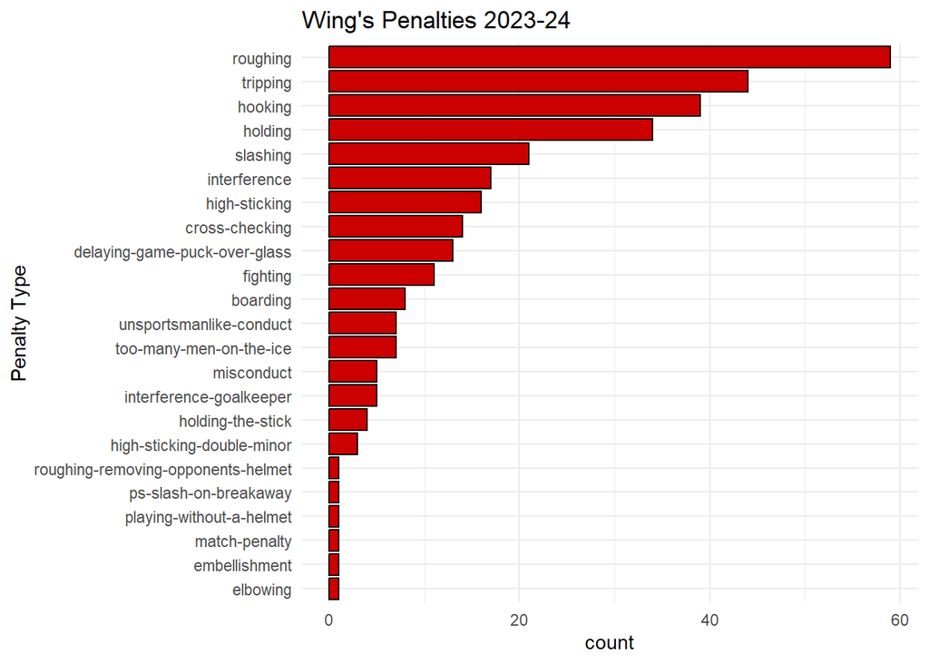

```r
Wings_penalty <- Wingspbp |> filter(event_type == "PENALTY")|>
  group_by(secondary_type)|>
  summarise(count = n())|>
  mutate(secondary_type = fct_reorder(secondary_type, count))


ggplot(data = Wings_penalty, aes(x = secondary_type, y = count))+
  geom_col(fill = "red3", colour = "black")+
  coord_flip()+
  theme_minimal()+
  labs(x = "Penalty Type", title = "Wing's Penalties 2023-24")
```

Looking at the bar plot we can see that the Wings had a big problem with roughing penalties this season. A roughing penalty is defined as “using arms, hands, or stick in a careless or reckless manner”, to me roughing is a discipline issue with the team that needs to be assessed by the coaching staff. All though call’s by the ref can go both ways it is up to the player to stay calm and think about the team first. A penalty like Fighting is more disciplined because it usually doesn’t result in the opposing team getting a power play (odd man advantage for 2 minutes) instead both players go to the penalty box. In order to make it to playoffs next season the Wing’s need to limit the penalties out of frustration, penalties will happen but being more disciplined as a team would be the answer to this question.

## The proportion of penalties the Red Wings took per game compared to other NHL teams:

```r
pbp|> filter(event_type == "PENALTY")|>
  group_by(event_team)|>
  summarise(pen_per_game = n()/82)|> ##82 games in the season
  mutate(event_team = fct_reorder(event_team, pen_per_game),
         pen_per_game = round(pen_per_game, 2))|>
  arrange(pen_per_game)|>
  kable(caption = "NHL Average Penalties per Game", row.names = TRUE, align = 'c')
```

NHL Average Penalties per Game

|  | event_team | pen_per_game |
| --- | --- | --- |
| 1 | St. Louis Blues | 3.22 |
| 2 | Vegas Golden Knights | 3.24 |
| 3 | Seattle Kraken | 3.27 |
| 4 | Pittsburgh Penguins | 3.35 |
| 5 | New York Islanders | 3.52 |
| 6 | Chicago Blackhawks | 3.56 |
| 7 | Columbus Blue Jackets | 3.57 |
| 8 | Washington Capitals | 3.57 |
| 9 | Winnipeg Jets | 3.61 |
| 10 | Dallas Stars | 3.70 |
| 11 | New Jersey Devils | 3.70 |
| 12 | Buffalo Sabres | 3.77 |
| 13 | Detroit Red Wings | 3.82 |
| 14 | San Jose Sharks | 3.82 |
| 15 | Calgary Flames | 3.89 |
| 16 | Philadelphia Flyers | 3.91 |
| 17 | Los Angeles Kings | 4.04 |
| 18 | Nashville Predators | 4.04 |
| 19 | Ottawa Senators | 4.16 |
| 20 | Carolina Hurricanes | 4.23 |
| 21 | Tampa Bay Lightning | 4.23 |
| 22 | Toronto Maple Leafs | 4.24 |
| 23 | Minnesota Wild | 4.28 |
| 24 | Montreal Canadiens | 4.28 |
| 25 | Colorado Avalanche | 4.29 |
| 26 | Arizona Coyotes | 4.39 |
| 27 | Vancouver Canucks | 4.52 |
| 28 | New York Rangers | 4.56 |
| 29 | Boston Bruins | 4.87 |
| 30 | Edmonton Oilers | 5.12 |
| 31 | Anaheim Ducks | 5.38 |
| 32 | Florida Panthers | 6.34 |

The Detroit Red Wings ranked 13th with an average of 3.82 penalties every game, not terribly bad in terms of discipline but would like to see them bring the average down to closer to 3 penalties a game next season. As you can see teams like Vegas, Dallas, and Islanders are at the top and these are teams that made it into the 2024 Stanley Cup Playoffs. As I said above undisciplined penalties like roughing, tripping, hooking, and slashing need to be limited if the Wing’s want a shot at the playoff’s next season.

## Proportion of blocked shots Red Wings had per game compared to other NHL teams:

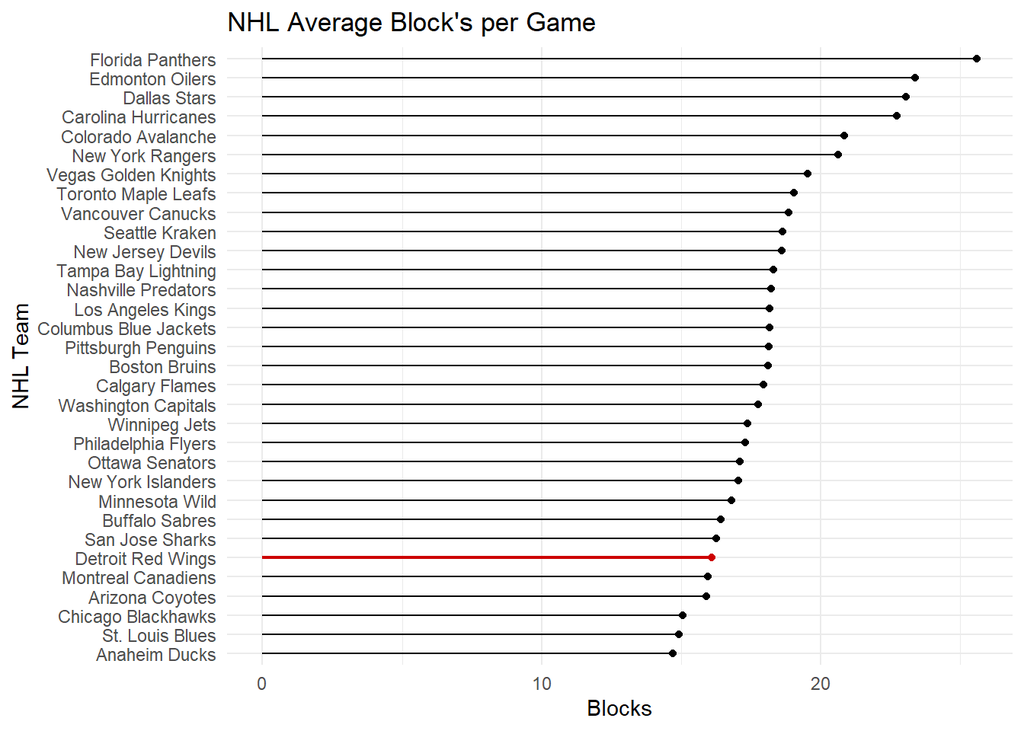

```r
Wings_blocks <- Wingspbp|> filter(event_type == "BLOCKED_SHOT")|>
  group_by(event_team)|>
  summarise(blocked_per_game = n()/82) ##82 games in the season

nhl_blocks <- pbp|> filter(event_type == "BLOCKED_SHOT")|>
  group_by(event_team)|>
  summarise(blocked_per_game = n()/82)|> ##82 games in the season
  mutate(event_team = fct_reorder(event_team, blocked_per_game))|>
  arrange(desc(blocked_per_game))|>
  filter(!is.na(event_team))

ggplot(data = nhl_blocks, aes(x = event_team, y = blocked_per_game)) +
  geom_segment(aes(xend = event_team, y = 0, yend = blocked_per_game))+
  geom_point() +
  geom_segment(data = Wings_blocks, aes(xend = event_team, y = 0, yend = blocked_per_game),
               color = "red3", linewidth = .8) +
  geom_point(data = Wings_blocks, color = "red3") +
  coord_flip() +
  theme_minimal()+
  labs(x = "NHL Team", y = "Blocks", title = "NHL Average Block's per Game")
```

The Detroit Red Wings ranked 27th in the NHL with an average of 16.1 blocked shots per game which is not good. The Wing’s getting the 16.1 up to a 17.5/18 blocks per game would give the Red Wings a better shot to making playoffs next year. This could start by bringing in a guy who is known for his defense and penalty kill skills.

## Red Wing’s power play percentage compared to other teams:

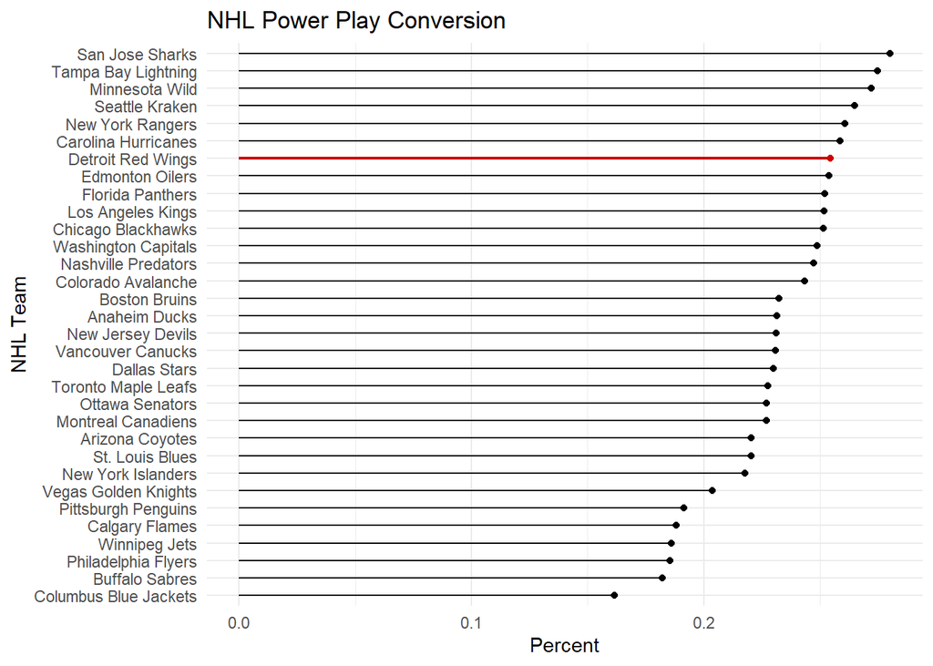

```r
Wings_pp <- Wingsgoals|> mutate(pp_goal = str_detect(strength_code, pattern = "PP"))|>
  select(pp_goal, everything())|>
  filter(!is.na(pp_goal))|>
  group_by(event_team)|>
  summarise(pp_percent = mean(pp_goal))

nhl_pp <- pbp|> filter(event_type == "GOAL")|>
  mutate(pp_goal = str_detect(strength_code, pattern = "PP"))|>
  filter(!is.na(pp_goal))|>
  group_by(event_team)|>
  summarise(pp_percent = mean(pp_goal))|>
  mutate(event_team = fct_reorder(event_team, pp_percent))|>
  arrange(desc(pp_percent))

ggplot(data = nhl_pp, aes(x = event_team, y = pp_percent)) +
  geom_segment(aes(xend = event_team, y = 0, yend = pp_percent)) +
  geom_point() +
  geom_segment(data = Wings_pp, aes(xend = event_team, y = 0, yend = pp_percent),
               color = "red3", linewidth = .8)+
  geom_point(data = Wings_pp, color = "red3")+
  coord_flip() +
  theme_minimal()+
  labs(x = "NHL Team", y = "Percent", title = "NHL Power Play Conversion")
```

## Red Wings goal’s scored ranked in 2023-2024 with a shot plot for type of goal scored:

```r
pbp|> filter(event_type == "GOAL")|>
  group_by(event_team)|>
  summarise(goals = n())|>
  arrange(desc(goals))|>
  kable(cation = "Total Goal's Scored per Team", row.names = TRUE, align = 'c')
```

|  | event_team | goals |
| --- | --- | --- |
| 1 | Edmonton Oilers | 384 |
| 2 | Dallas Stars | 354 |
| 3 | Colorado Avalanche | 347 |
| 4 | Florida Panthers | 345 |
| 5 | New York Rangers | 334 |
| 6 | Carolina Hurricanes | 320 |
| 7 | Toronto Maple Leafs | 319 |
| 8 | Vancouver Canucks | 312 |
| 9 | Tampa Bay Lightning | 307 |
| 10 | Boston Bruins | 303 |
| 11 | Vegas Golden Knights | 286 |
| 12 | Nashville Predators | 284 |
| 13 | Detroit Red Wings | 280 |
| 14 | Los Angeles Kings | 277 |
| 15 | Winnipeg Jets | 274 |
| 16 | New Jersey Devils | 264 |
| 17 | New York Islanders | 262 |
| 18 | Pittsburgh Penguins | 260 |
| 19 | Arizona Coyotes | 257 |
| 20 | Calgary Flames | 256 |
| 21 | Ottawa Senators | 256 |
| 22 | Minnesota Wild | 254 |
| 23 | Buffalo Sabres | 249 |
| 24 | Montreal Canadiens | 245 |
| 25 | St. Louis Blues | 243 |
| 26 | Columbus Blue Jackets | 239 |
| 27 | Philadelphia Flyers | 237 |
| 28 | Washington Capitals | 231 |
| 29 | Seattle Kraken | 222 |
| 30 | Anaheim Ducks | 205 |
| 31 | San Jose Sharks | 185 |
| 32 | Chicago Blackhawks | 181 |

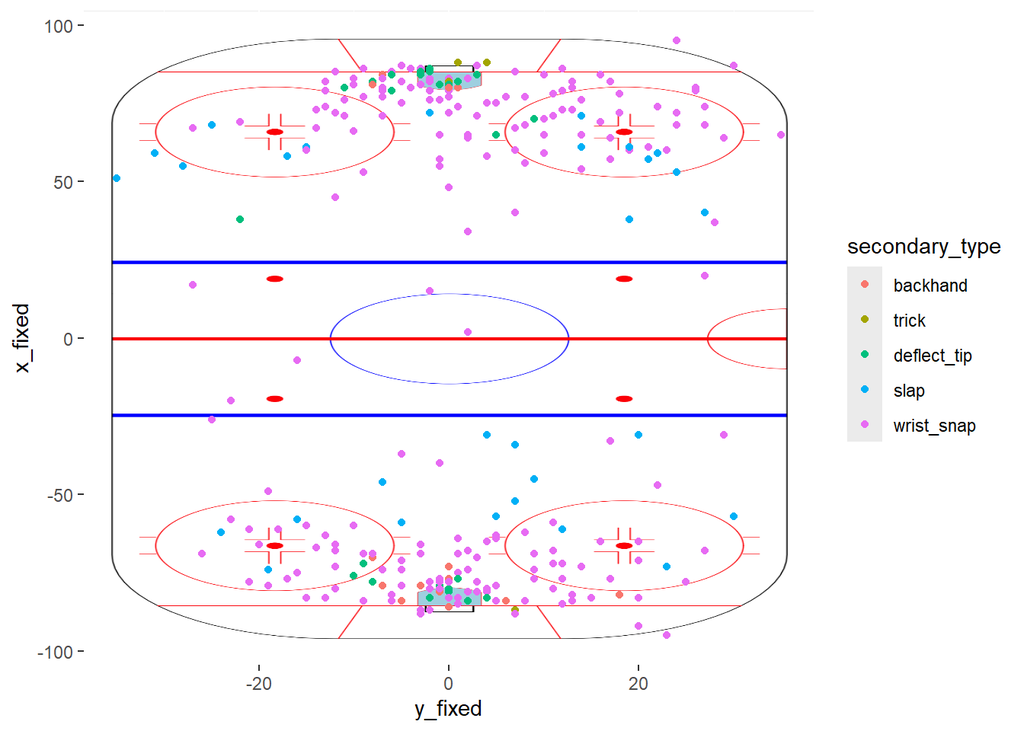

```r
ggplot(data = Wingsgoals, aes(x = x_fixed, y = y_fixed, color = secondary_type))+
  geom_shotplot()
```

Table: The Detroit Red Wing’s ranked 13th in the NHL which is not bad for goals scored this season! If the Wing’s continue to produce goal’s they should find themselves in a good spot for next year in the rank’s for playoffs.

Shot Plot: We can see that most of the goals that were scored were either a wrist shot or snapshot, which mean’s they were taken on the forehand of their stick which is common for a goal. The negative end of the rink on the x-fixed from the red line down meant it was an away goal scored and the positive side of the x-fixed meant it was a home goal scored. Each dot represents the area on the rink where the player had shot the puck to score, some are from center ice meaning it was most likely an empty net goal.

## Conclusion:

Overall, the Detroit Red Wing’s had a good season in terms of offensive production. Some things that the Wing’s need to work on is the discipline in their system, this can be addressed by leaders and coaches as we see it can cost them. Only 16 out of the 32 NHL teams make the Stanley Cup Playoff’s each year and it is important that each game is taken serious out of the 82 regular season games they play. To wrap up, penalties need to be controlled more, there need to be more blocked shots next year, the Wing’s need to continue to convert on the power play chances, and the Wing’s need to produce more goals in order to make it into the Stanley Cup Playoff’s for next year.